# DAT301-Project1

Yailin Corona-Ruezga

2025-04-17

When looking for data sets, I found this one the most interesting due to the fact that data is the newest form of currency that can be exploited if in the wrong hands. I thought this data set could offer insights for cyber security teams, a country’s governmental institutions, and independent companies to create a more secure and resistant company to these attacks. This data set explores 10 countries in the attacks made against them and their people. It notes the year,the amount of users that were affected, the amount of financial loss, the industry it impacted, the attack type, the attack source, the vulnerability, the defense against the attack, and the overall time it took to mitigate the attack. This data set was provided by Atharva Soundankar from India on Kaggle.com.

## 1) Frequency of Attacks by Country

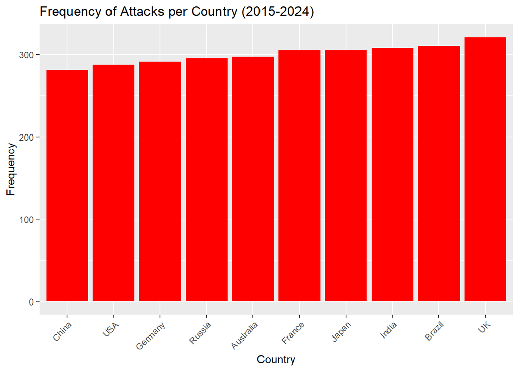

This graph shows which country had the most attacks from 2015-2024. This range is between 280-325 attacks in 10 years. China has least and the United Kingdom leads out of the 10 countries noted.This overall information organizes which countries have a a higher track record of being targeted, this can help cyber security groups have insights on which countries are more likely to be targeted. Although the difference between these ten countries isn’t too drastic, it still offers some insight.

## 2) Frequency of Attack Types

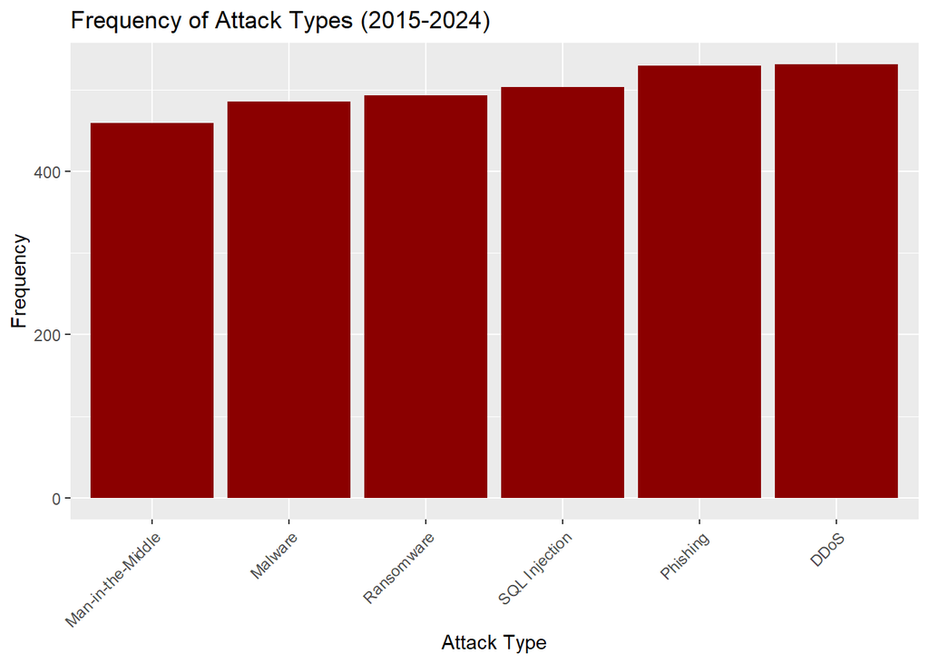

This graph notes the attack type and their frequency. These attack types have a very similar frequency amounts but this can help companies and industries decide the types of protections they implement as well as training to have their workers complete to avoid attack types such as phishing. This can also create implementations on testing against their security in order to avoid these types of attacks.

## 3) Frequency of Attacks per Industry

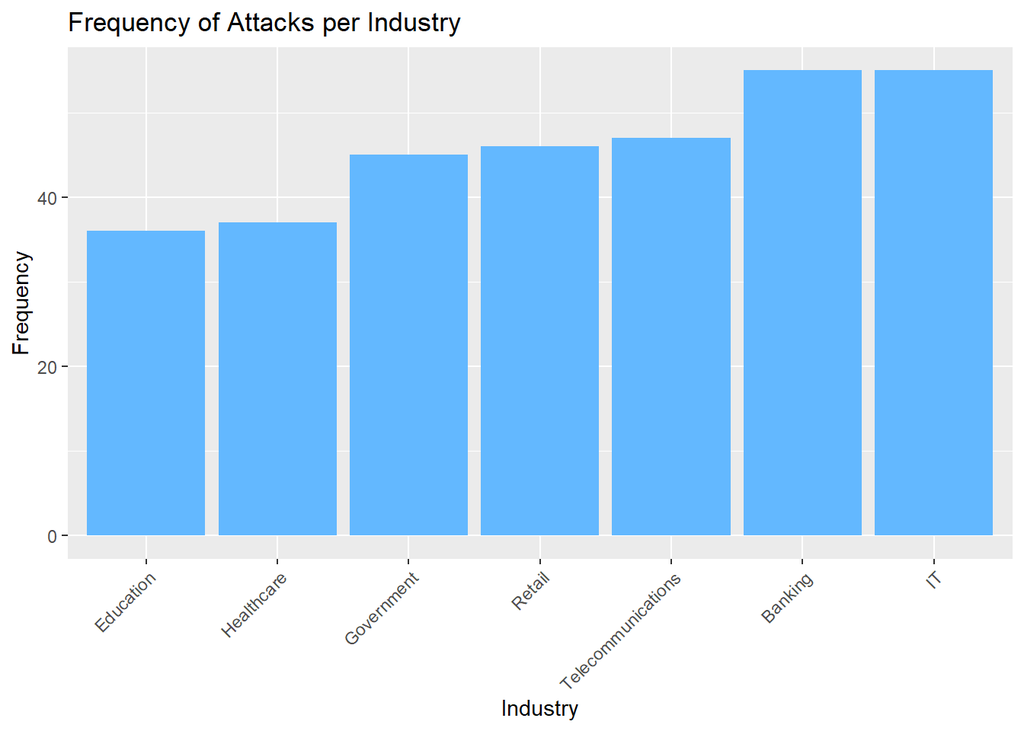

## 4) Average financial loss per Country

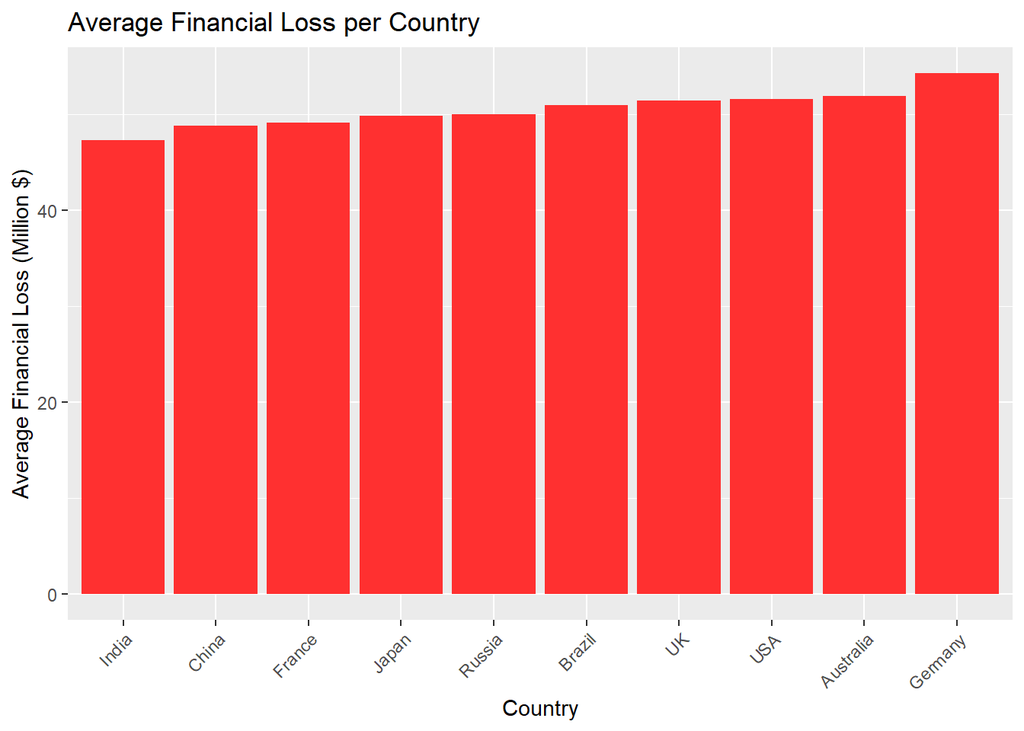

This visual is more pertinent to governments for each of these countries than individual companies. When compared to the first one that notes the amount of overall attacks, this visual notes the countries with the highest average financial loss, Germany, and it did not have the overall highest amount of attacks, the UK. These two visuals can help governmental institutions create legislation in order to help mitigate the average amount of loss and hopefully reduce the amount of successful attacks made against their people.

## 5) Highest vs Lowest Number of Affected Users

```
## # A tibble: 10 × 3
##    Country   lowest highest
##    <chr>      <dbl>   <dbl>
##  1 Australia   6670  994468
##  2 Brazil       984  993826
##  3 China       4814  998728
##  4 France       424  999545
##  5 Germany     1326  998028
##  6 India        586  999542
##  7 Japan       2653  991854
##  8 Russia      7290  988889
##  9 UK           735  998547
## 10 USA         1068  999635
```

Going more in depth to note the amount of actual user’s affected by attacks. Each country have similar amount of users when looking at the higher amount, but their lower end of the range become more varying. Just like any other data set, a range is important to note that no matter the size of company or the data stored within a secured firewall. Any company can become a target because any information is vital for user privacy.

## 6) Box plot for each Country’s Affected Users

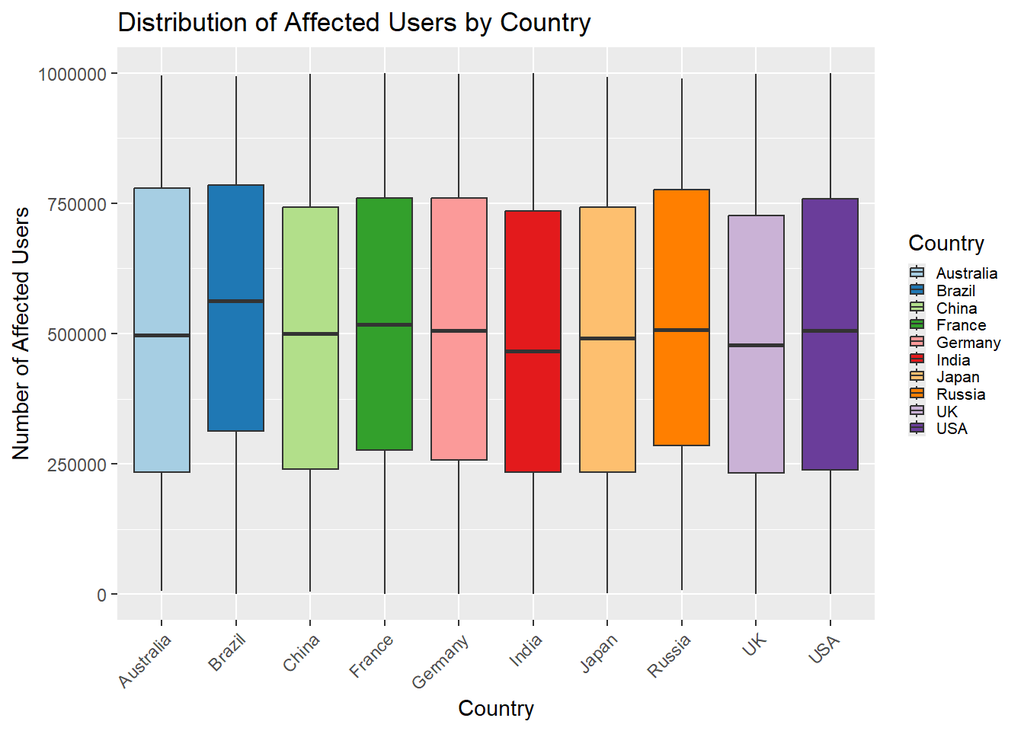

## 7) Average Affected User vs Average Financial Loss per Country.

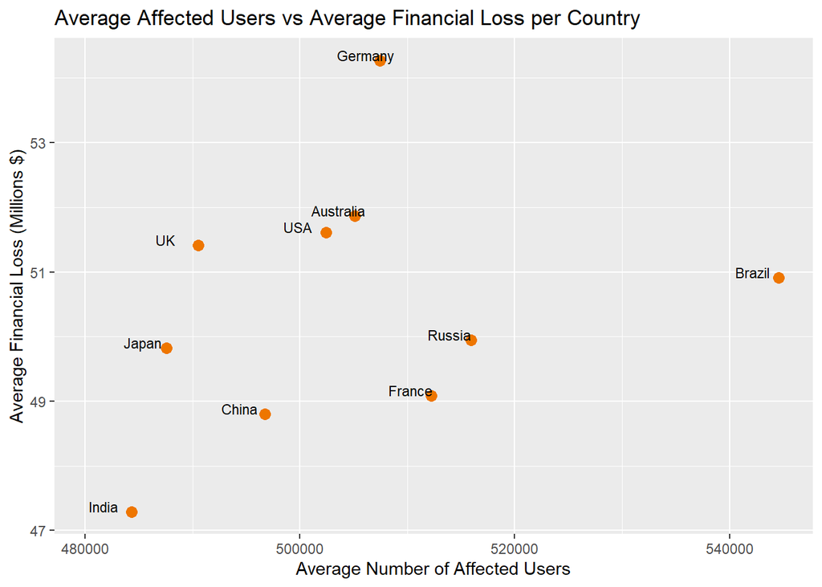

Although most companies would like to reduce the amount of affected users and lost private data, these companies would also like avoid loss of money from fixing the issue, creating stronger cyber security, and much more. This can visually show countries and companies that although many users were not affected, there can still be significant financial loss and vice versa.

## 8) Attacks per Country from 2015-2024

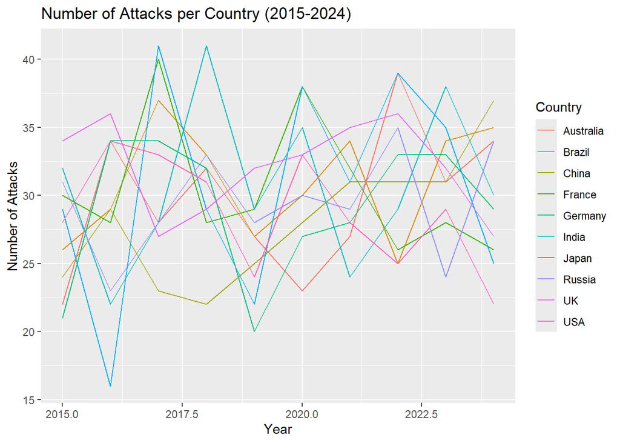

Although there is no obvious trends for any countries when it comes to the number of attacks per year, taking note of each one individually may help governments or companies can note where they began compared to how they ended in successful attacks.

## 9) Average Response Time per Country (2015-2019 vs 2020-2024)

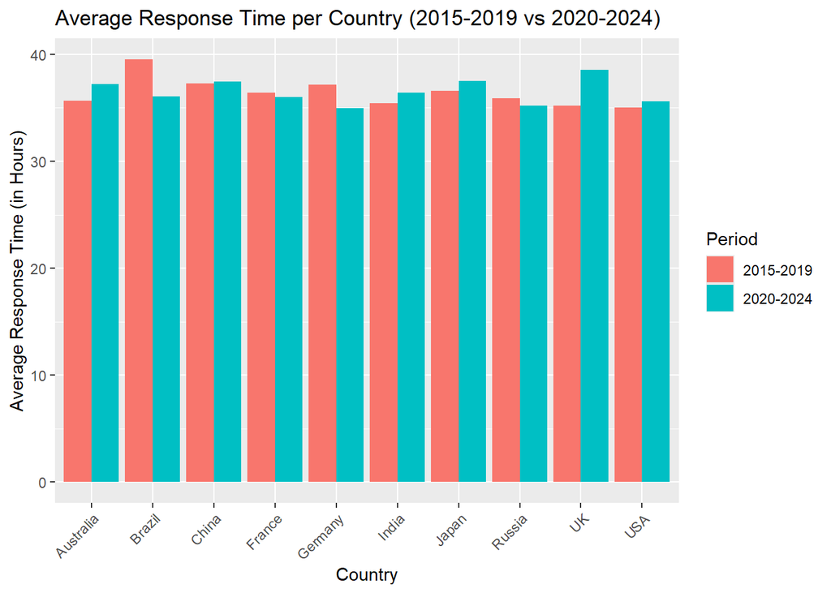

Although most countries to do not have a large difference in the average response times from the two 5 year differences, This assures that although technology is always advancing and security measures are always being restructured and strengthened, this doesn’t have an overall impact when it come to across the board in most countries. Just like security measures are being improved, security attacks are doing the same.

## 10) Country’s fastest and Slowest Response Time

```
## # A tibble: 10 × 4
##    Country   fastest_resp slowest_resp ave_resp
##    <chr>            <dbl>        <dbl>    <dbl>
##  1 Australia            1           72     36.5
##  2 Brazil               1           72     37.8
##  3 China                1           72     37.4
##  4 France               2           72     36.2
##  5 Germany              1           72     36.0
##  6 India                1           72     35.9
##  7 Japan                1           72     37.1
##  8 Russia               1           72     35.5
##  9 UK                   1           72     36.9
## 10 USA                  1           72     35.3
```

## 11) Number of Affected Uusers vs Financial Loss by Industry

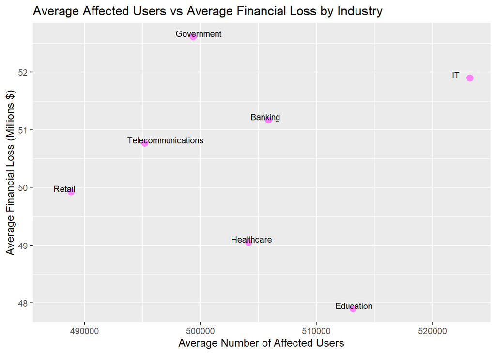

This visual highlights the industries and their average affected users vs their financial loss. For example, the cyber attacks made against Education Industries affect a high amount of people, but has a low amount of financial loss, on the opposite side, the Governments do not have as high as a number of affected users, but does have the highest amount of financial loss compared to the other industries. Also, IT has an equally high amount of affected users and financial loss. These data points can visually show where companies can focus their security measures and how their choices impact their users and their company financially.

## 12)Table of Industry’s Ave Affected Users, Ave Loss in Millions

```
## # A tibble: 7 × 3
##   Target.Industry    ave_affected_users ave_loss_in_mill
##   <chr>                           <dbl>            <dbl>
## 1 Banking                       505839.             51.2
## 2 Education                     513138.             47.9
## 3 Government                    499352.             52.6
## 4 Healthcare                    504130.             49.0
## 5 IT                            523211.             51.9
## 6 Retail                        488833.             49.9
## 7 Telecommunications            495204.             50.8
```

This chart gives a number for each industry from the visual above.

## 13) Average Response Time for Each Attack Type

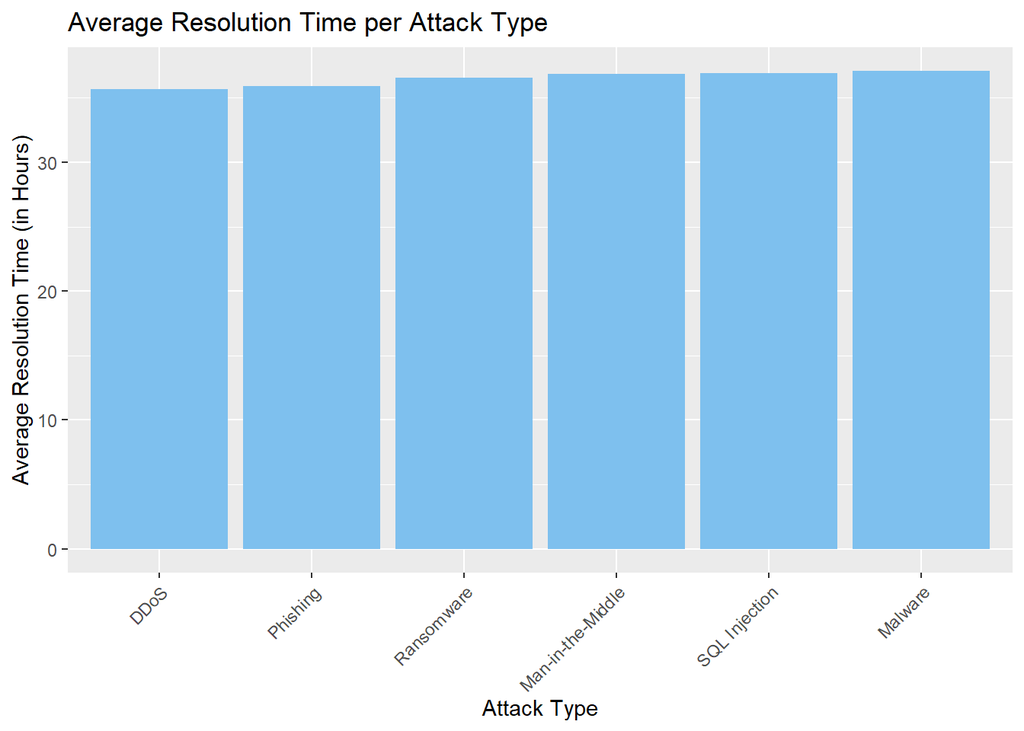

Another point this data set can highlight is no form of attack is easier to solve than others. Attacks come in a variety of difficulties and should each be taken seriously due to the impacts it can cause the users in loss data information and companies in financial loss.

## Conclusion

This data set is an overall view of information companies and governments should look at in order to improve their own security measures. Data sets that are this large and show a wider scope of what is going on in cyber attacks do not show a direct correlation to what is happening inside companies. This data set is supposed to be a guidance on where to start. This proactive view can save not only money but the new currency in today’s age, data.